# foe_green_space_eda_1

```r
library(tidyverse)
```

```r
library(readxl)
library(RColorBrewer)
library(cowplot)

theme_set(theme_minimal())
```

Local Authority District to Region lookup (December 2019 used) - https://geoportal.statistics.gov.uk/datasets/3ba3daf9278f47daba0f561889c3521a_0

```r
green_space <- read_excel("../Data/(FOE) Green Space Consolidated Data - England - Version 2.1.xlsx",
                          sheet = "MSOAs V2.1")
```

```
## * `` -> ...1
```

```r
green_space
```

```
## # A tibble: 6,791 x 38
##     ...1 MSOA_Code MSOA_Name MSOA_Name_House~ LA_Code LA_Name LA_Name_For_Rea~
##    <dbl> <chr>     <chr>     <chr>            <chr>   <chr>   <chr>
##  1     1 E02000001 City of ~ City of London   E09000~ City o~ City of London
##  2     2 E02000002 Barking ~ Marks Gate       E09000~ Barkin~ Barking and Dag~
##  3     3 E02000003 Barking ~ Chadwell Heath ~ E09000~ Barkin~ Barking and Dag~
##  4     4 E02000004 Barking ~ Eastbrookend     E09000~ Barkin~ Barking and Dag~
##  5     5 E02000005 Barking ~ Becontree Heath  E09000~ Barkin~ Barking and Dag~
##  6     6 E02000007 Barking ~ Central Park & ~ E09000~ Barkin~ Barking and Dag~
##  7     7 E02000008 Barking ~ Becontree East   E09000~ Barkin~ Barking and Dag~
##  8     8 E02000009 Barking ~ Becontree West   E09000~ Barkin~ Barking and Dag~
##  9     9 E02000010 Barking ~ Dagenham North   E09000~ Barkin~ Barking and Dag~
## 10    10 E02000011 Barking ~ Dagenham Eastbr~ E09000~ Barkin~ Barking and Dag~
## # ... with 6,781 more rows, and 31 more variables: Area <dbl>,
## #   Population_IMD <dbl>, Population_Density <dbl>,
## #   Total_Pop_From_Ethnicity_Data <dbl>, White_Pop <dbl>,
## #   Mixed_Multiple_Ethnic_Group_Pop <dbl>, Asian_AsianBritish_Pop <dbl>,
## #   Black_African_Caribbean_BlackBritish_Pop <dbl>,
## #   Other_Ethnic_Group_Pop <dbl>, BAME_Pop <dbl>, Income_Index <dbl>,
## #   GreenSpace_Area <dbl>, GreenSpace_Area_Per_Capita <dbl>,
## #   Unbuffered_GOSpace_Area <dbl>, Buffrd_GOSpace_Area <dbl>,
## #   Unbuffered_GOSpace_Per_Capita <dbl>, Pop_Area <dbl>,
## #   PopArea_With_GOSpace_Access <dbl>, Pcnt_PopArea_With_GOSpace_Access <dbl>,
## #   Pcnt_Pop_With_GOSpace_Access <dbl>, Pcnt_Pop_Without_GOSpace_Access <dbl>,
## #   Pop_Without_GOSpace_Access <dbl>, Garden_Area_Houses <dbl>,
## #   Garden_Area_Flats <dbl>, Garden_Area_Total <dbl>,
## #   Garden_Area_Per_Capita <dbl>, GSDI_AvgArea <dbl>, GSDI_Access <dbl>,
## #   GSDI_Garden <dbl>, Green_Space_Deprivation_Score <dbl>,
## #   Green_Space_Deprivation_Rating <chr>
```

```r
# FOE green space data doesn't include a variable for the region each MSOA/local authority lies within
# So, import a look up table from the ONS, which maps between Local Authority Districts and Regions
LAD_to_region <- read_csv("../Data/Local_Authority_District_to_Region__December_2019__Lookup_in_England.csv") %>%
  select(-FID, -LAD19NM)
LAD_to_region
```

```
## # A tibble: 317 x 3
##    LAD19CD   RGN19CD   RGN19NM
##    <chr>     <chr>     <chr>
##  1 E09000001 E12000007 London
##  2 E09000002 E12000007 London
##  3 E07000064 E12000008 South East
##  4 E09000003 E12000007 London
##  5 E09000004 E12000007 London
##  6 E09000005 E12000007 London
##  7 E07000065 E12000008 South East
##  8 E07000066 E12000006 East of England
##  9 E09000006 E12000007 London
## 10 E09000007 E12000007 London
## # ... with 307 more rows
```

```r
# add region names and codes (from ONS look up) to FOE green space data
green_space <- green_space %>%
  left_join(LAD_to_region, by = c("LA_Code" = "LAD19CD")) %>%
  relocate(RGN19CD, RGN19NM, .before = Area) %>%
  rename(region_code = RGN19CD,
         region_name = RGN19NM)

green_space
```

```
## # A tibble: 6,791 x 40
##     ...1 MSOA_Code MSOA_Name MSOA_Name_House~ LA_Code LA_Name LA_Name_For_Rea~
##    <dbl> <chr>     <chr>     <chr>            <chr>   <chr>   <chr>
##  1     1 E02000001 City of ~ City of London   E09000~ City o~ City of London
##  2     2 E02000002 Barking ~ Marks Gate       E09000~ Barkin~ Barking and Dag~
##  3     3 E02000003 Barking ~ Chadwell Heath ~ E09000~ Barkin~ Barking and Dag~
##  4     4 E02000004 Barking ~ Eastbrookend     E09000~ Barkin~ Barking and Dag~
##  5     5 E02000005 Barking ~ Becontree Heath  E09000~ Barkin~ Barking and Dag~
##  6     6 E02000007 Barking ~ Central Park & ~ E09000~ Barkin~ Barking and Dag~
##  7     7 E02000008 Barking ~ Becontree East   E09000~ Barkin~ Barking and Dag~
##  8     8 E02000009 Barking ~ Becontree West   E09000~ Barkin~ Barking and Dag~
##  9     9 E02000010 Barking ~ Dagenham North   E09000~ Barkin~ Barking and Dag~
## 10    10 E02000011 Barking ~ Dagenham Eastbr~ E09000~ Barkin~ Barking and Dag~
## # ... with 6,781 more rows, and 33 more variables: region_code <chr>,
## #   region_name <chr>, Area <dbl>, Population_IMD <dbl>,
## #   Population_Density <dbl>, Total_Pop_From_Ethnicity_Data <dbl>,
## #   White_Pop <dbl>, Mixed_Multiple_Ethnic_Group_Pop <dbl>,
## #   Asian_AsianBritish_Pop <dbl>,
## #   Black_African_Caribbean_BlackBritish_Pop <dbl>,
## #   Other_Ethnic_Group_Pop <dbl>, BAME_Pop <dbl>, Income_Index <dbl>,
## #   GreenSpace_Area <dbl>, GreenSpace_Area_Per_Capita <dbl>,
## #   Unbuffered_GOSpace_Area <dbl>, Buffrd_GOSpace_Area <dbl>,
## #   Unbuffered_GOSpace_Per_Capita <dbl>, Pop_Area <dbl>,
## #   PopArea_With_GOSpace_Access <dbl>, Pcnt_PopArea_With_GOSpace_Access <dbl>,
## #   Pcnt_Pop_With_GOSpace_Access <dbl>, Pcnt_Pop_Without_GOSpace_Access <dbl>,
## #   Pop_Without_GOSpace_Access <dbl>, Garden_Area_Houses <dbl>,
## #   Garden_Area_Flats <dbl>, Garden_Area_Total <dbl>,
## #   Garden_Area_Per_Capita <dbl>, GSDI_AvgArea <dbl>, GSDI_Access <dbl>,
## #   GSDI_Garden <dbl>, Green_Space_Deprivation_Score <dbl>,
## #   Green_Space_Deprivation_Rating <chr>
```

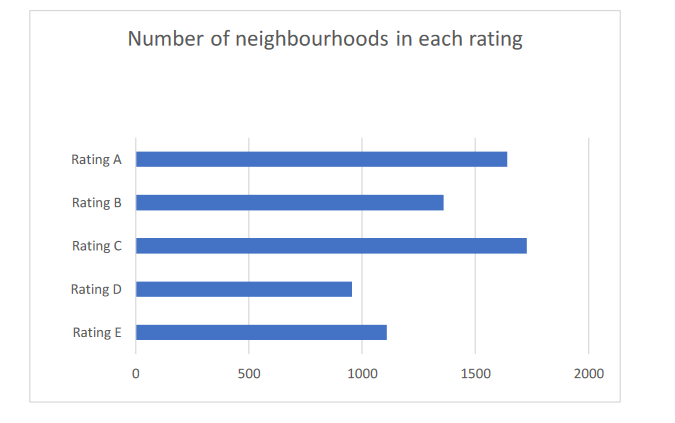

```r
title_lab <- "Numbers of neighbourhoods in England by green space\ndeprivation rating\n"
subtitle_lab <- "E is highest level of green space deprivation\n\nA is lowest level of green space deprivation"
x_lab <-  "Green space deprivation rating\n\n"
y_lab <-  "\nNumber of Neighbourhoods\n"
caption_lab <-  "Source: Friends of the Earth, England's Green Space Gap"

msoa_by_rating <- green_space %>%
  group_by(Green_Space_Deprivation_Rating) %>%
  summarise(msoa_count = n()) %>%
  add_column(bar_label = c("Large or very large gardens and large or \nvery large amounts of public green space",
                           "",
                           "",
                           "",
                           "Very small gardens and very small\namounts of public green space") # add labels to be used on the plot
             ) %>%
  ungroup() %>%
  mutate(prop_rating = msoa_count / sum(msoa_count))
msoa_by_rating
```

```
## # A tibble: 5 x 4
##   Green_Space_Deprivat~ msoa_count bar_label                         prop_rating
##   <chr>                      <int> <chr>                                   <dbl>
## 1 A                           1641 "Large or very large gardens and~       0.242
## 2 B                           1360 ""                                      0.200
## 3 C                           1727 ""                                      0.254
## 4 D                            955 ""                                      0.141
## 5 E                           1108 "Very small gardens and very sma~       0.163
```

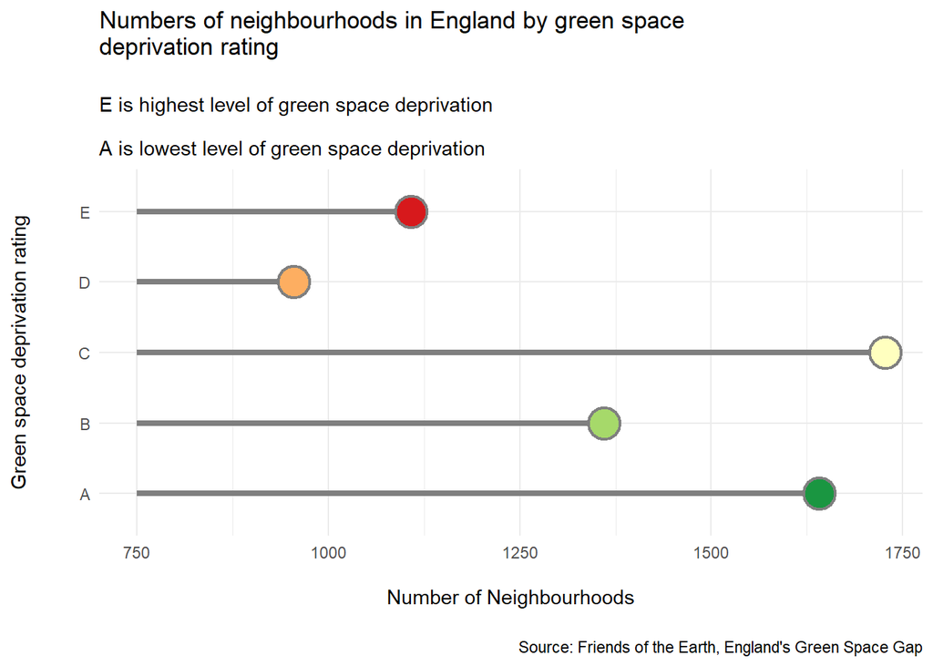

```r
p <- ggplot(data = msoa_by_rating,
            mapping = aes(x = Green_Space_Deprivation_Rating, y = msoa_count)
            )

p + geom_segment(mapping = aes(x = Green_Space_Deprivation_Rating,
                               xend = Green_Space_Deprivation_Rating,
                               y = 750,
                               yend = msoa_count),
                 colour = "grey50",
                 size = 1.5
                 ) +

  geom_point(mapping = aes(fill = Green_Space_Deprivation_Rating),
             size = 7.5,
             shape = 21,
             colour = "grey50",
             stroke = 1.25
             ) +

  scale_fill_brewer(type = "div",
                    palette = "RdYlGn",
                    direction = -1) +


  labs(title = title_lab,
       subtitle = subtitle_lab,
       x = x_lab,
       y = y_lab,
       caption = caption_lab) +

  guides(fill = FALSE) +

  # facet_wrap(~ Green_Space_Deprivation_Rating) +

  coord_flip()
```

## The distribution of green space deprivation ratings across England

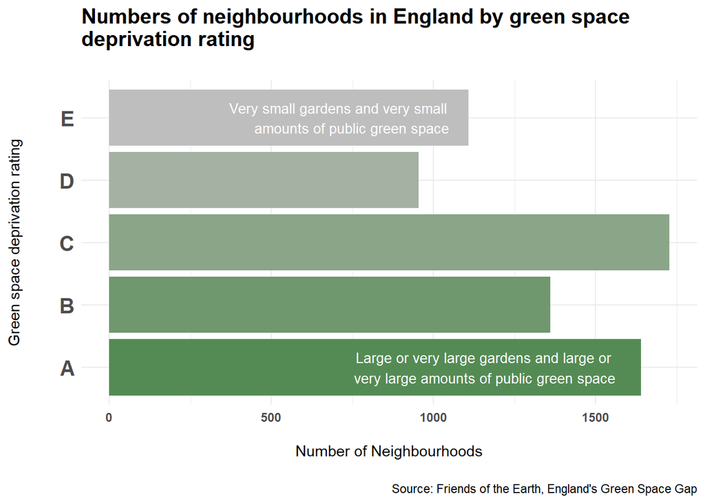

```r
colour_palette <- scales::seq_gradient_pal(low = "palegreen4", high = "grey")
colour_scale <- colour_palette(seq(0, 1, length.out = 5))
#colour_scale <- c("springgreen4", "palegreen4", "darkseagreen3", "grey75", "grey60")

p + geom_bar(mapping = aes(fill = Green_Space_Deprivation_Rating),
             stat = "identity") +

  scale_fill_manual(values = colour_scale) +

  geom_text(mapping = aes(label = bar_label), hjust = 1.1, colour = "white", size = 3.5) +

  guides(fill = FALSE) +

  labs(title = title_lab,
       x = x_lab,
       y = y_lab,
       caption = caption_lab) +

  theme(axis.text.x = element_text(face = "bold"),
        axis.text.y = element_text(face = "bold", size = 15),
        plot.title = element_text(face = "bold", size = 15)
        ) +

  coord_flip()
```

Below I plot the proportions of the 6791 MSOAs analyzed given each green space deprivation rating.

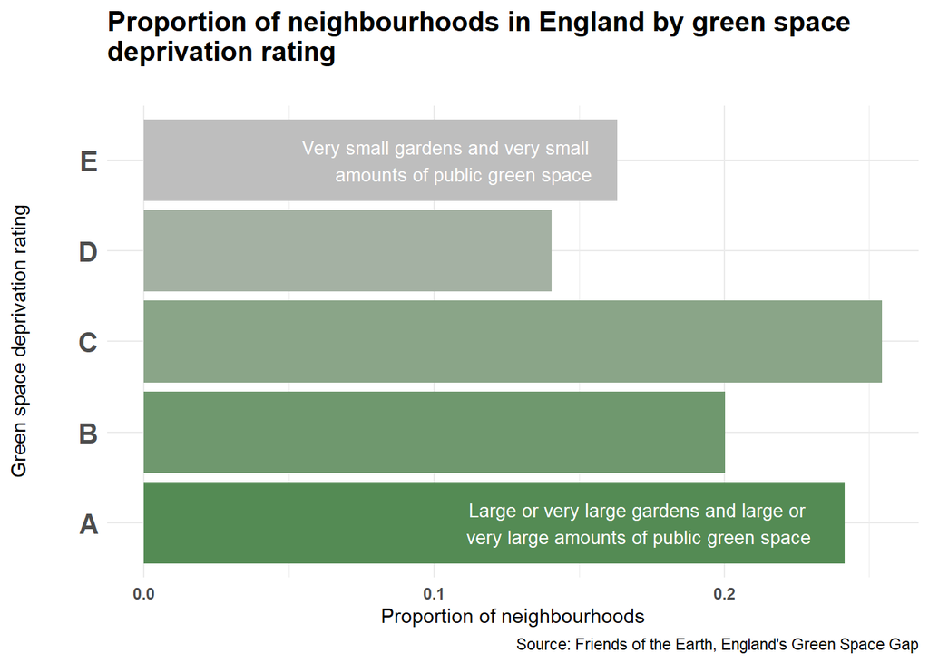

```r
p <- ggplot(data = msoa_by_rating,
            mapping = aes(x = Green_Space_Deprivation_Rating, y = prop_rating)
            )

p + geom_bar(mapping = aes(fill = Green_Space_Deprivation_Rating),
             stat = "identity") +

  scale_fill_manual(values = colour_scale) +

  geom_text(mapping = aes(label = bar_label), hjust = 1.1, colour = "white", size = 3.5) +

  guides(fill = FALSE) +

  labs(title = "Proportion of neighbourhoods in England by green space\ndeprivation rating\n",
       x = x_lab,
       y = "Proportion of neighbourhoods",
       caption = caption_lab) +

  theme(axis.text.x = element_text(face = "bold"),
        axis.text.y = element_text(face = "bold", size = 15),
        plot.title = element_text(face = "bold", size = 15)
        ) +

  coord_flip()
```

```r
msoa_by_rating
```

```
## # A tibble: 5 x 4
##   Green_Space_Deprivat~ msoa_count bar_label                         prop_rating
##   <chr>                      <int> <chr>                                   <dbl>
## 1 A                           1641 "Large or very large gardens and~       0.242
## 2 B                           1360 ""                                      0.200
## 3 C                           1727 ""                                      0.254
## 4 D                            955 ""                                      0.141
## 5 E                           1108 "Very small gardens and very sma~       0.163
```

## The distribution of green space deprivation ratings across the regions

The two plots below, respectively show for each region the numbers or proportion of MSOA with each green space deprivation rating. Key insights from the two plots include:

```r
msoa_by_region_and_rating <- green_space %>%

  # count by region and rating
  group_by(region_name, Green_Space_Deprivation_Rating) %>%
  summarise(msoa_count = n()) %>%
  filter(!is.na(region_name)) %>%
  ungroup() %>%

  # calculate rating proportions by region
  group_by(region_name) %>%
  mutate(prop = msoa_count / sum(msoa_count)) %>%
  ungroup()
msoa_by_region_and_rating
```

```
## # A tibble: 45 x 4
##    region_name     Green_Space_Deprivation_Rating msoa_count   prop
##    <chr>           <chr>                               <int>  <dbl>
##  1 East Midlands   A                                     153 0.267
##  2 East Midlands   B                                     134 0.234
##  3 East Midlands   C                                     193 0.337
##  4 East Midlands   D                                      43 0.0750
##  5 East Midlands   E                                      50 0.0873
##  6 East of England A                                     236 0.321
##  7 East of England B                                     131 0.178
##  8 East of England C                                     229 0.311
##  9 East of England D                                      77 0.105
## 10 East of England E                                      63 0.0856
## # ... with 35 more rows
```

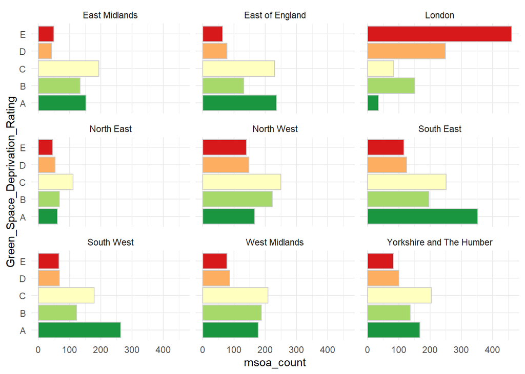

```r
plot_msoas_by_region <-  function(y_var){

  p <- ggplot(data = msoa_by_region_and_rating,
            mapping = aes(x = Green_Space_Deprivation_Rating, y = .data[[y_var]])
            )

  p + geom_bar(mapping = aes(fill = Green_Space_Deprivation_Rating),
             stat = "identity",
             colour = "grey80") +

  scale_fill_brewer(type = "div",
                    palette = "RdYlGn",
                    direction = -1) +

  guides(fill = FALSE) +

  coord_flip() +

  facet_wrap(~ region_name, ncol = 3)
}

plot_msoas_by_region("msoa_count")
```

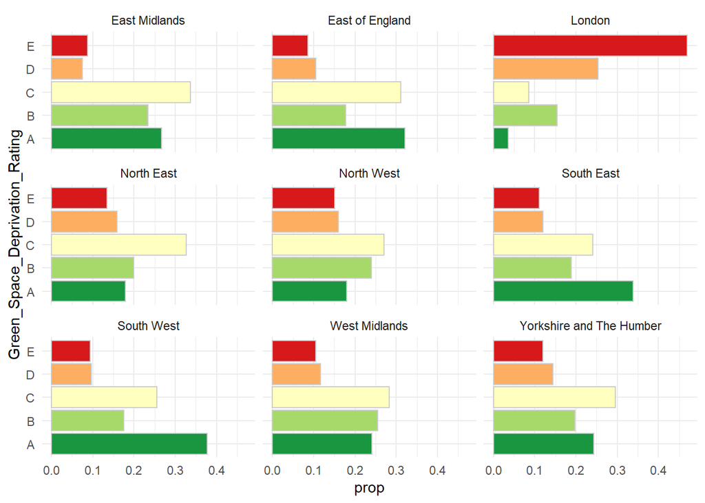

```r
plot_msoas_by_region("prop")
```

Below I plot again plot the proportion of MSOAs within each region receiving each green space deprivation rating. This time faceting the plot by green space deprivation rating rather than region. This makes it easier to compare across regions at a given rating.

- So we can clearly see the South East and Southwest have higher proportions of A rated MSOAs than say the North East and North West.
- While outside of London, within each region there are similar proportion of neighbourhoods receiving the two highest green space deprivation ratings (D and E).

It would be easier to read if I produced separate plots for each green space deprivation rating, as then the regions could be put in rank order.

```r
prop_a <- msoa_by_region_and_rating %>%
  filter(Green_Space_Deprivation_Rating == "A") %>%
  mutate(prop_a = prop) %>%
  select(region_name, prop_a)

msoa_by_region_and_rating <- msoa_by_region_and_rating %>%
  left_join(prop_a)
msoa_by_region_and_rating
```

```
## # A tibble: 45 x 5
##    region_name     Green_Space_Deprivation_Rating msoa_count   prop prop_a
##    <chr>           <chr>                               <int>  <dbl>  <dbl>
##  1 East Midlands   A                                     153 0.267   0.267
##  2 East Midlands   B                                     134 0.234   0.267
##  3 East Midlands   C                                     193 0.337   0.267
##  4 East Midlands   D                                      43 0.0750  0.267
##  5 East Midlands   E                                      50 0.0873  0.267
##  6 East of England A                                     236 0.321   0.321
##  7 East of England B                                     131 0.178   0.321
##  8 East of England C                                     229 0.311   0.321
##  9 East of England D                                      77 0.105   0.321
## 10 East of England E                                      63 0.0856  0.321
## # ... with 35 more rows
```

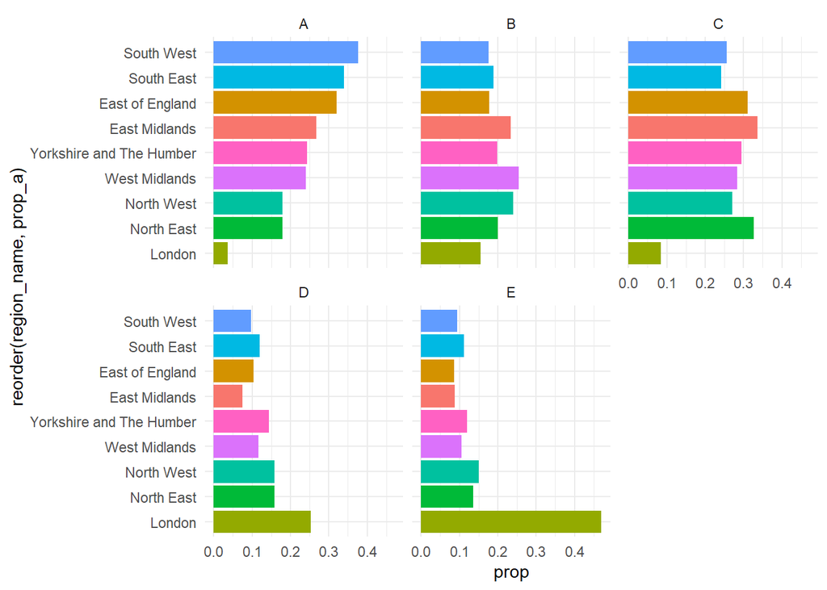

```r
p <- ggplot(data = msoa_by_region_and_rating,
            mapping = aes(x = reorder(region_name, prop_a), y = prop, fill = region_name)
            )

p + geom_bar(stat = "identity") +
  facet_wrap(~ Green_Space_Deprivation_Rating) +

  guides(fill = FALSE) +

  coord_flip()
```

Next I explored an alternative appraoch to considering the distribution of msoas by rating and region. I plotted the proportion of MSOAs that received a specific rating by region. In order to address the ordering issue above, I produced one plot for each green space rating. This meant addressing the challenge of how to ensure the colour associated with a given region was applied consistently across the five plots. Here is where I found the an approach to doing this, using scale_…_manual.

[How to map a colour to a value of a categorical variable …](https://www.stat.ubc.ca/~jenny/STAT545A/block17_colorsGgplot2Qualitative.html)

This approach help me identify some additional insights:

- For the highest green space deprivation ratings (D and E), the ranking of regions is the same: (1) London, (2) North West, (3) South East, (4) Yorkshire and the Humber and (5) West Midlands.
- Over half of MSOAs given the highest green space deprivation rating are accounted for by just two regions: (1) London and (2) the North West.

```r
# The idea is to produce one bar chart for each green space rating, and across these plots use the same colour for a given region.
# choose a palette to work with
region_pal <- brewer.pal(9, "Paired")

# map the region names to a specific colour value (in a dataframe for ease)
region_colours_df <- msoa_by_region_and_rating %>%
  select(region_name) %>%
  distinct(region_name) %>%
  add_column(colour = region_pal)

# convert the region-colour mapping from a dataframe to a vector
# because a vector is required by scale_fill_manual
region_colours_vector <- region_colours_df$colour
names(region_colours_vector) <- region_colours_df$region_name
region_colours_vector
```

```
##            East Midlands          East of England                   London
##                "#A6CEE3"                "#1F78B4"                "#B2DF8A"
##               North East               North West               South East
##                "#33A02C"                "#FB9A99"                "#E31A1C"
##               South West            West Midlands Yorkshire and The Humber
##                "#FDBF6F"                "#FF7F00"                "#CAB2D6"
```

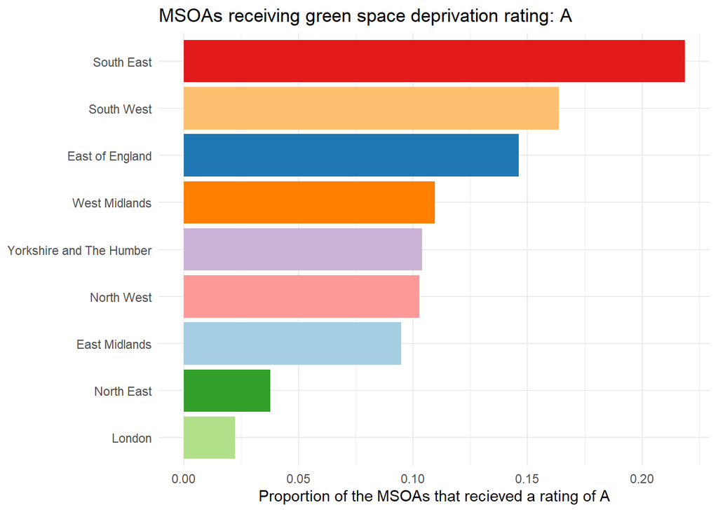

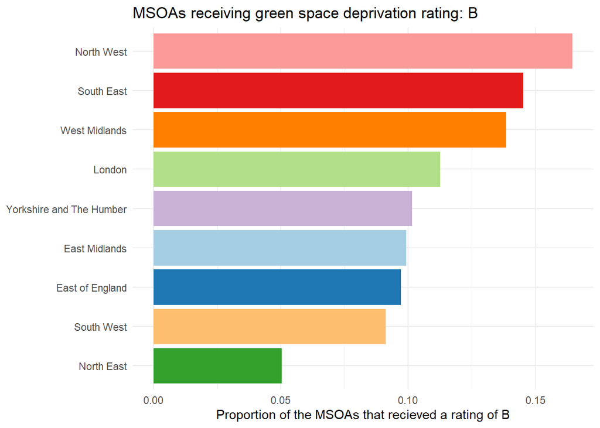

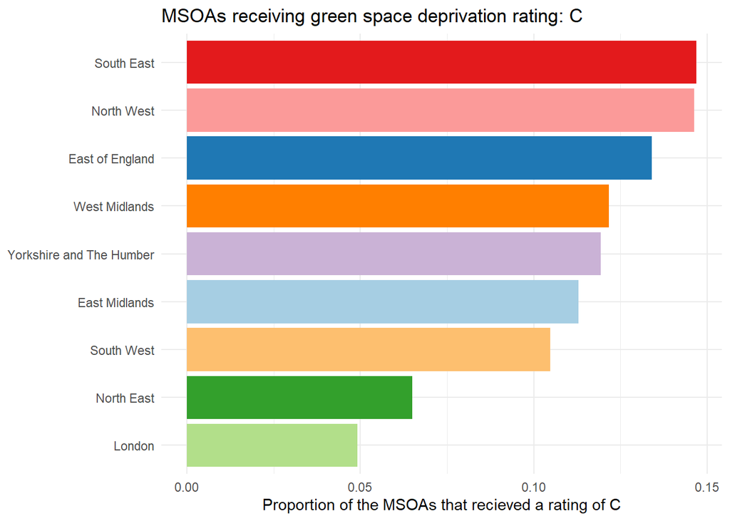

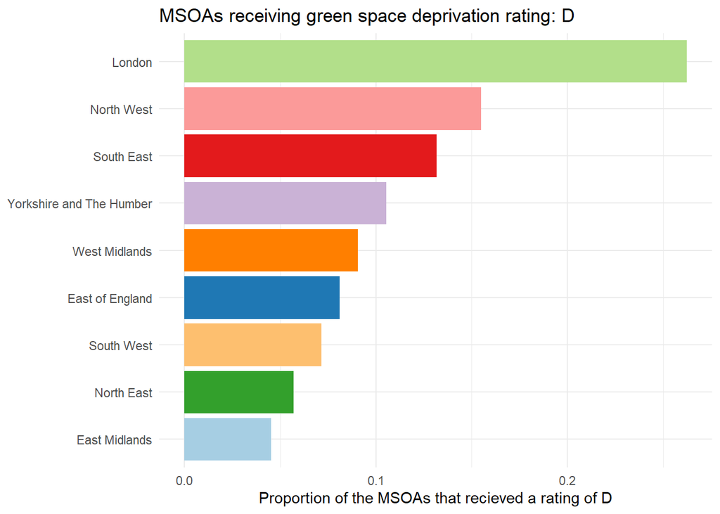

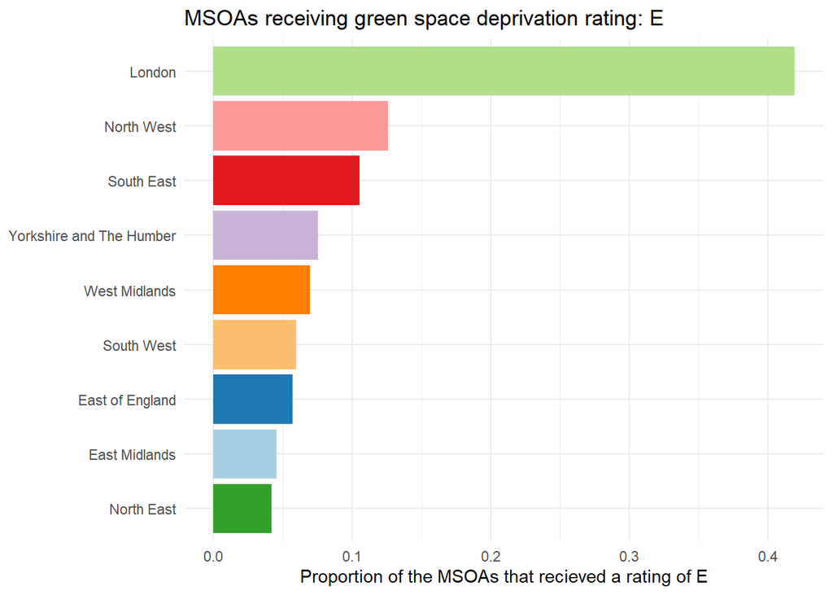

```r
plot_gsdr_prop_by_region <- function(rating = "A"){

    msoa_by_region_and_rating %>%

    # focus on the rating of interest
    filter(Green_Space_Deprivation_Rating == rating) %>%
    mutate(proportion = msoa_count / sum(msoa_count)) %>%

    # create the bar chart
    ggplot(mapping = aes(x = reorder(region_name, proportion),
                         y = proportion,
                         fill = region_name
                         )
           ) +

    geom_col() +

    # apply region-colour mapping
    scale_fill_manual(values = region_colours_vector) +

    guides(fill = FALSE) +

    labs(title = str_c("MSOAs receiving green space deprivation rating: ", rating),
         x = NULL,
         y = str_c("Proportion of the MSOAs that recieved a rating of ", rating)
         ) +

    coord_flip()
}


# produce one plot for each of the five green space deprivation ratings
gsdr_prop_by_region_plots <- c("A", "B", "C", "D", "E") %>%
  map(~ plot_gsdr_prop_by_region(.x))

gsdr_prop_by_region_plots
```

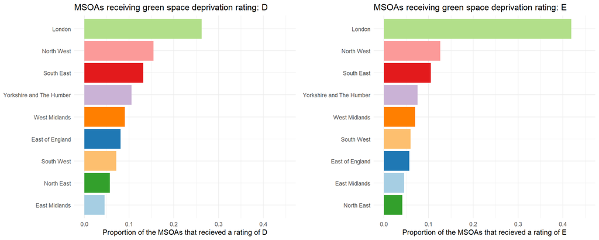

```r
d_plot <- gsdr_prop_by_region_plots[[4]] +
  ylim(0, 0.45) # ensure the plot axis scales match

e_plot <- gsdr_prop_by_region_plots[[5]] +
  ylim(0, 0.45) # ensure the plot axis scales match

plot_grid(d_plot, e_plot, ncol = 2)
```

Could do ridgeline plots for each region - for prop rated A and proportion rated E

## The geographic distribution of green space deprivation ratings

https://datacarpentry.org/r-raster-vector-geospatial/06-vector-open-shapefile-in-r/

```r
library(sf)
msoa_sf <- st_read("../Data/Middle_Layer_Super_Output_Areas/Middle_Layer_Super_Output_Areas__December_2011__Boundaries_EW_BFE.shp")
# msoa_sf <- raster::shapefile("../Data/Middle_Layer_Super_Output_Areas/Middle_Layer_Super_Output_Areas__December_2011__Boundaries_EW_BFE.shp")



msoa_sf_gs <- msoa_sf %>%
  left_join(green_space, by = c("MSOA11CD" = "MSOA_Code"))
```

A quick visual inspection of the MSOAs colored by their green space deprivation rating, shows a similiar patter across the regions (with the exception of London). With the the D and E ratings (oranges and reds) occurring in smaller (presumably more densely populated MSOAs) which make up urban areas. While the larger, more rural MSOAs tend to be less green space deprived, and have A or B ratings. Given the whole region of London would probably be considered a continuous urban space, it is unsurprising to observe many green space deprived MSOAs across the region/plot, with relatively few less green space deprived areas present.

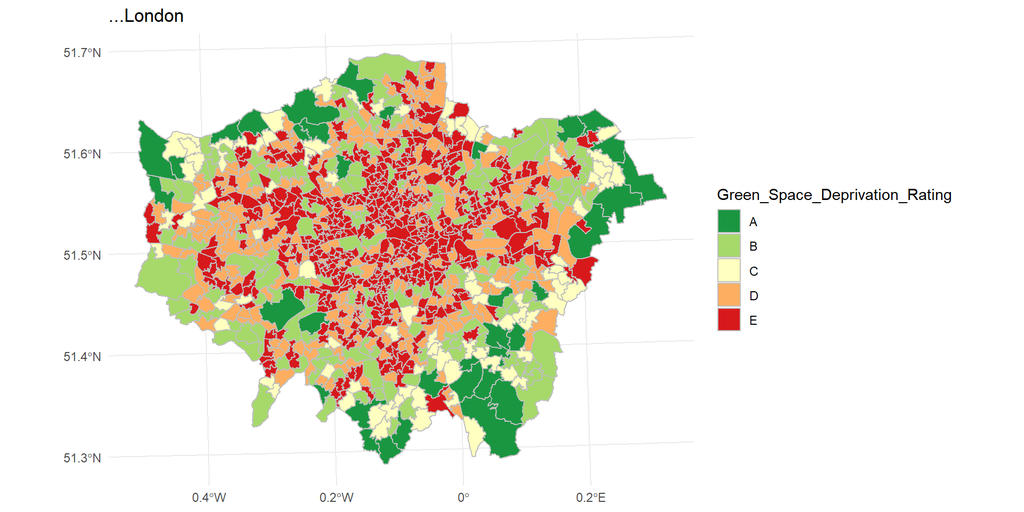

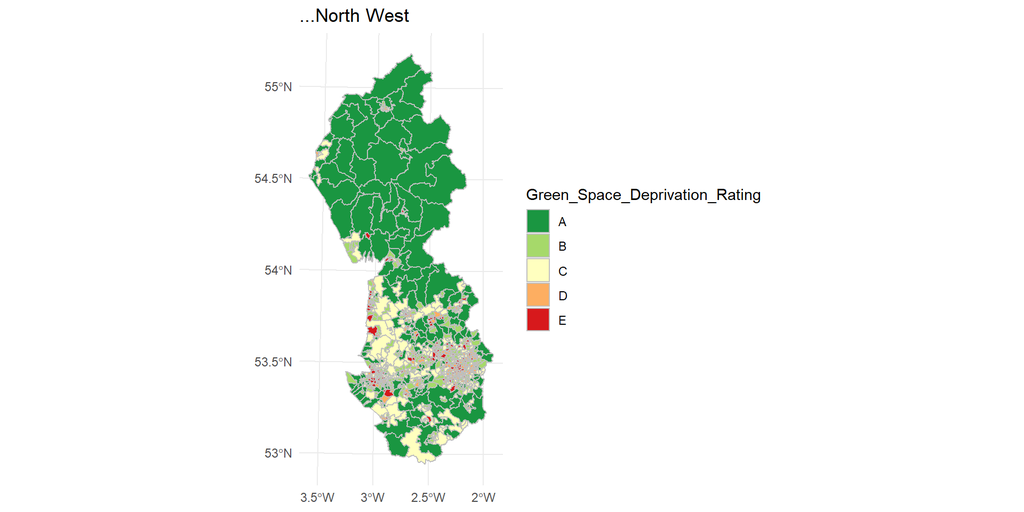

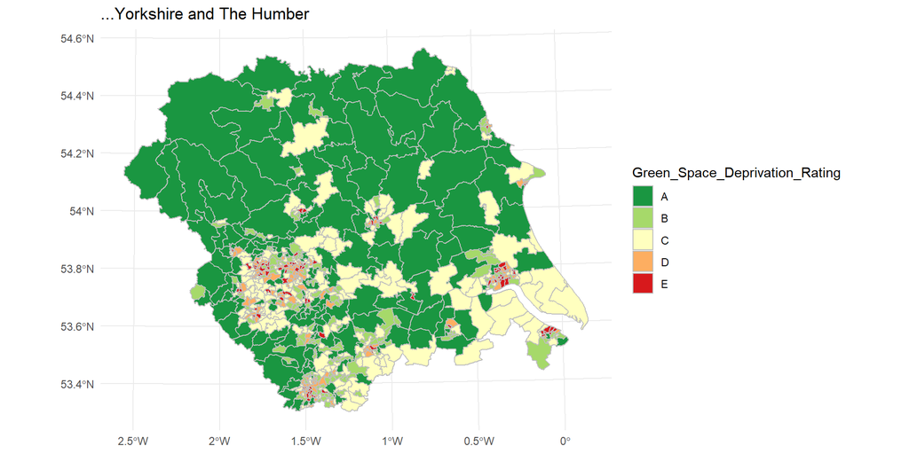

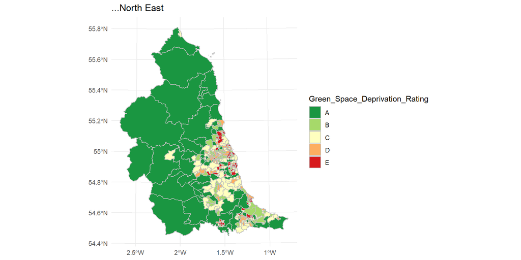

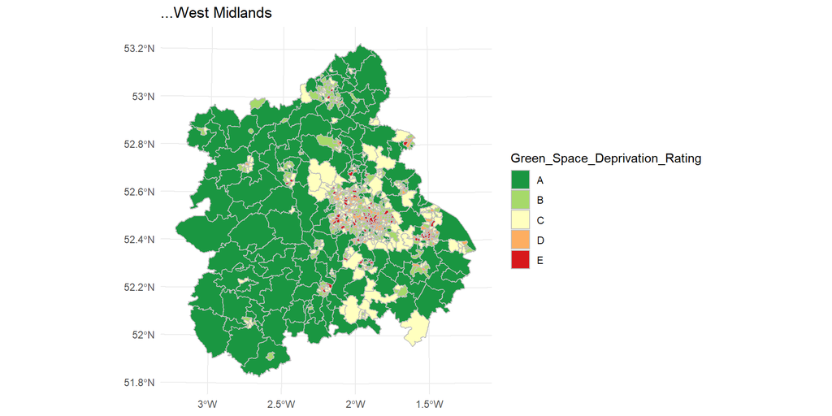

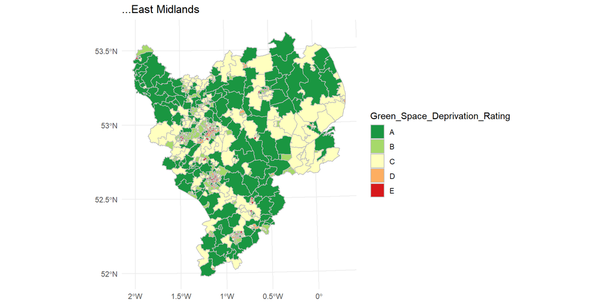

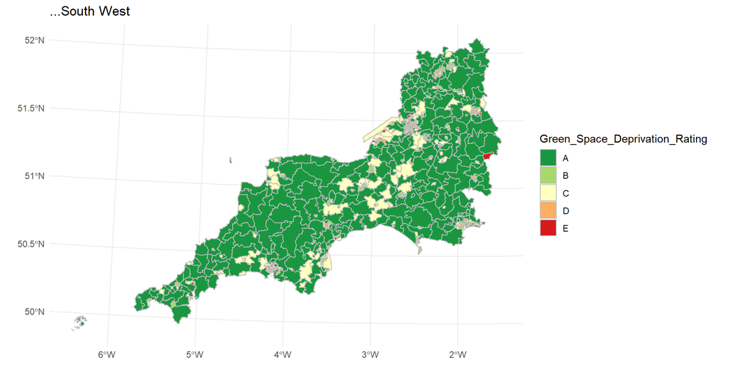

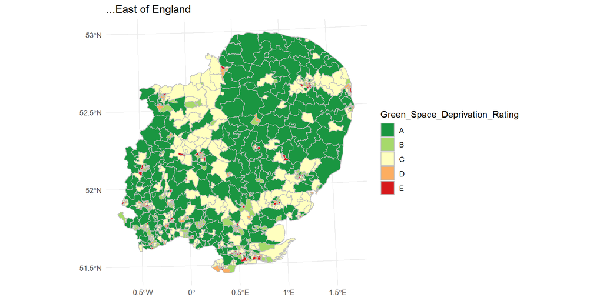

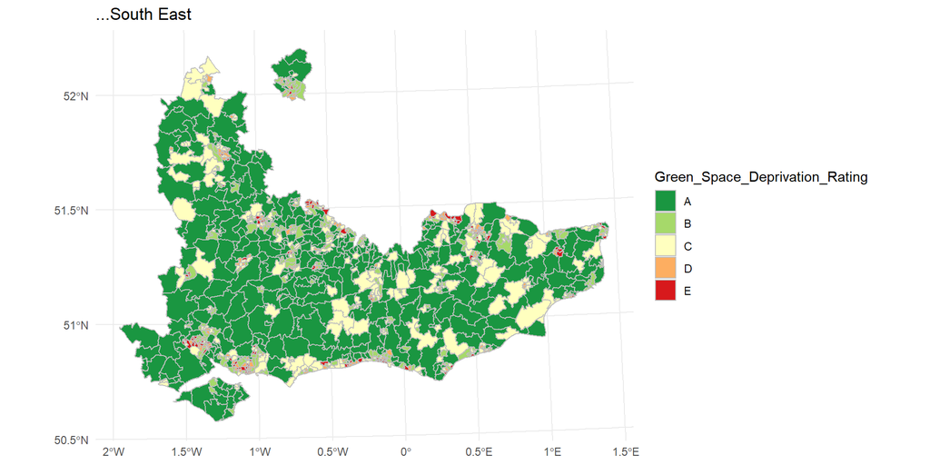

```r
green_space_region_plot <- function(region){

  p <-  ggplot(data = msoa_sf_gs %>%
                 filter(region_name == region),
               mapping = aes(fill = Green_Space_Deprivation_Rating)
               )

  p + geom_sf(colour = "grey75") +

    scale_fill_brewer(type = "div",
                      palette = "RdYlGn",
                      direction = -1) +

    labs(title = str_c("...", region))
}

region_names <- green_space %>%
  select(region_name) %>%
  distinct(region_name)

region_names %>%
  filter(!is.na(region_name)) %>%
  pmap(~ green_space_region_plot(region = .x))
```

# Ethnicity and green space deprivation

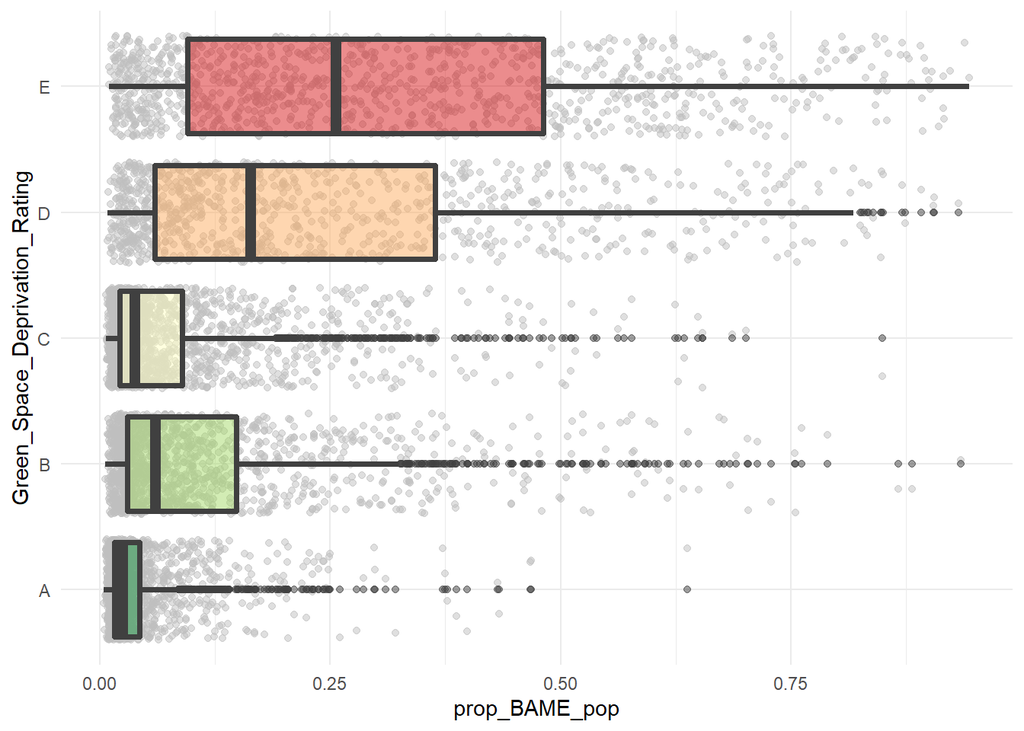

```r
green_space <- green_space %>%
  mutate(prop_BAME_pop = BAME_Pop / Total_Pop_From_Ethnicity_Data) %>%
  relocate(prop_BAME_pop, .after = BAME_Pop)

p <- ggplot(data = green_space,
            mapping = aes(x = Green_Space_Deprivation_Rating,
                          y = prop_BAME_pop)
            )

p + geom_jitter(alpha = 0.5, colour = "grey75") +
  geom_boxplot(mapping = aes(fill = Green_Space_Deprivation_Rating),
               alpha = 0.5,
               size = 1.25,
               colour = "grey25") +

  scale_fill_brewer(type = "div",
                      palette = "RdYlGn",
                      direction = -1) +

  guides(fill = FALSE) +

  coord_flip()
```

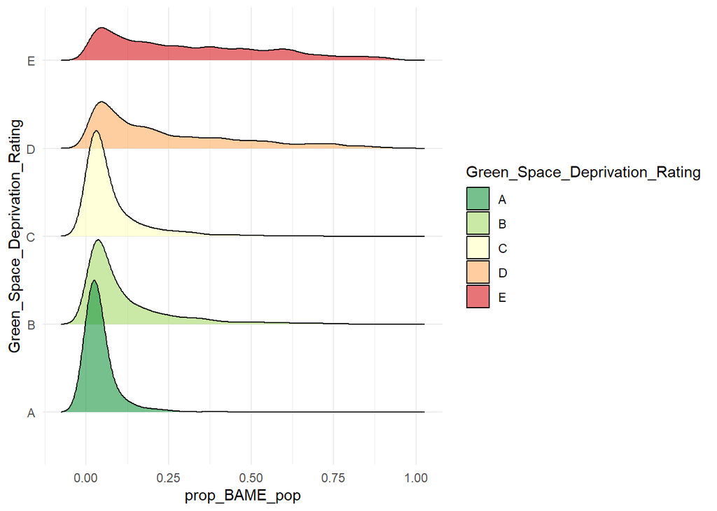

```r
library(ggridges)

p <- ggplot(data = green_space,
            mapping = aes(y = Green_Space_Deprivation_Rating,
                          x = prop_BAME_pop,
                          fill = Green_Space_Deprivation_Rating)
            )

p + geom_density_ridges(alpha = 0.6, scale = 1.5) +
  scale_fill_brewer(type = "div",
                      palette = "RdYlGn",
                      direction = -1)
```

# Wealth and green space deprivation

# Health and green space deprivation

## Covid and green space deprivation